# 2018_climate4R

SantanderMetGroup

2018-03-22

# 1 Introduction

Packages in `climate4R`:

```r
library(devtools)
install_github(c("SantanderMetGroup/loadeR",
                 "SantanderMetGroup/loadeR.java",
                 "SantanderMetGroup/transformeR",
                 "SantanderMetGroup/visualizeR",
                 "SantanderMetGroup/downscaleR",
                 "SantanderMetGroup/climate4R.climdex")
```

```r
library(loadeR)
library(transformeR)
library(visualizeR)
library(downscaleR)
library(climate4R.climdex)
```

# 2 Example 1: Climate Indices from CORDEX Projections

## 2.1 Loading, collocating and harmonizing data

Define the study area.

```r
lon <- c(-10, 20)
lat <- c(35, 46)
```

### 2.1.1 Cliamte data loading from OpenDap server: E-OBS observational data

Overview of the dataset with function `dataInventory`:

```r
eobs <- "http://opendap.knmi.nl/knmi/thredds/dodsC/e-obs_0.25regular/tx_0.25deg_reg_v16.0.nc"
di <- dataInventory(eobs)
```

Loading with `loadGridData`:

```r
SU <- loadGridData(eobs, var = "tx",
                    season = 1:12,
                    years = 1971:2000,
                    lonLim = lon,
                    latLim = lat,
                    aggr.m = "sum",
                    condition = "GT",
                    threshold = 25)
```

#### 2.1.1.1 Using a dictionary

Standard variable naming:

```r
## dictionary: standard names
C4R.vocabulary()
```

```
##    identifier                           standard_name           units
## 1        hurs               2-meter relative humidity               %
## 2     hursmax       maximum 2-meter relative humidity               %
## 3     hursmin       minimum 2-meter relative humidity               %
## 4         hus                       specific humidity         kg.kg-1
## 5        huss               2-meter specific humidity         kg.kg-1
## 6     hussmax       maximum 2-meter specific humidity         kg.kg-1
## 7     hussmin       minimum 2-meter specific humidity         kg.kg-1
## 8          lm                        land binary mask               1
## 9        orog                        surface altitude               m
## 10         ps           air pressure at surface level              Pa
## 11        psl               air pressure at sea level              Pa
## 12       rlds  surface downwelling longwave radiation           W.m-2
## 13       rlut              toa outgoing longwave flux           W.m-2
## 14       rsds surface downwelling shortwave radiation           W.m-2
```

[output cut: 21 more lines]

Create dic file (dictionary explained in the `loadeR` wiki: https://github.com/SantanderMetGroup/loadeR/wiki/Harmonization)

```r
file.create("dicEOBS.dic")
```

```
## [1] TRUE
```

```r
writeLines(c("identifier,short_name,time_step,lower_time_bound,upper_time_bound,cell_method,offset,scale,deaccum,derived,interface",
             "tasmax,tx,24h,0,24,max,0,1,0,0,"), "dicEOBS.dic")
```

Repit loading operation but using the created dictionaty file:

```r
SU <- loadGridData(eobs,
                         var = "tasmax",
                         season = 1:12,
                         lonLim = lon,
                         latLim = lat,
                         years = 1971:2000,
                         aggr.m = "sum",
                         threshold = 25,
                         condition = "GT",
                         dictionary = "dicEOBS.dic")
```

#### 2.1.1.2 Annual aggregation using `transformeR`

```r
SU.annual <- aggregateGrid(SU, aggr.y = list(FUN = "sum"))
```

#### 2.1.1.3 visualization using `visualizeR`

First we create color palettes

```r
library(RColorBrewer)
colstx <- rev(brewer.pal(n = 9, "Spectral"))
colsindex <- rev(brewer.pal(n = 9, "RdYlBu"))
colsdelta <- brewer.pal(n = 9, "Reds")
colsbias <- brewer.pal(n = 9, "PiYG")
colssd <- brewer.pal(n = 9, "Blues")
```

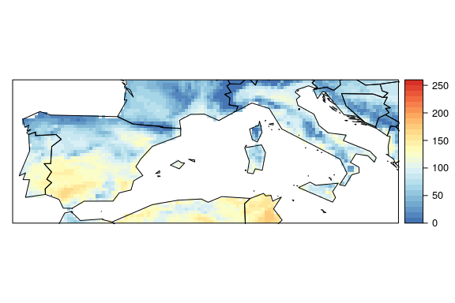

```r
spatialPlot(climatology(SU.annual), backdrop.theme = "countries",
            at = seq(0, 260, 10), col.regions = colorRampPalette(colsindex))
```

### 2.1.2 Cliamte data loading from local files: CORDEX climate change projections

```r
#historical data
wdch <- "/myDirectoryOfHistoricalData/"
#climate change data
wdc <- "/myDirectoryOfClimateChangeData/"
list.files(wdc, recursive = T)
```

```
##  [1] "tasmax_EUR-44_ICHEC-EC-EARTH_rcp85_r12i1p1_SMHI-RCA4_v1_day_20060101-20101231.nc"
##  [2] "tasmax_EUR-44_ICHEC-EC-EARTH_rcp85_r12i1p1_SMHI-RCA4_v1_day_20110101-20151231.nc"
##  [3] "tasmax_EUR-44_ICHEC-EC-EARTH_rcp85_r12i1p1_SMHI-RCA4_v1_day_20160101-20201231.nc"
##  [4] "tasmax_EUR-44_ICHEC-EC-EARTH_rcp85_r12i1p1_SMHI-RCA4_v1_day_20210101-20251231.nc"
##  [5] "tasmax_EUR-44_ICHEC-EC-EARTH_rcp85_r12i1p1_SMHI-RCA4_v1_day_20260101-20301231.nc"
##  [6] "tasmax_EUR-44_ICHEC-EC-EARTH_rcp85_r12i1p1_SMHI-RCA4_v1_day_20310101-20351231.nc"
##  [7] "tasmax_EUR-44_ICHEC-EC-EARTH_rcp85_r12i1p1_SMHI-RCA4_v1_day_20360101-20401231.nc"
##  [8] "tasmax_EUR-44_ICHEC-EC-EARTH_rcp85_r12i1p1_SMHI-RCA4_v1_day_20410101-20451231.nc"
##  [9] "tasmax_EUR-44_ICHEC-EC-EARTH_rcp85_r12i1p1_SMHI-RCA4_v1_day_20460101-20501231.nc"
## [10] "tasmax_EUR-44_ICHEC-EC-EARTH_rcp85_r12i1p1_SMHI-RCA4_v1_day_20510101-20551231.nc"
## [11] "tasmax_EUR-44_ICHEC-EC-EARTH_rcp85_r12i1p1_SMHI-RCA4_v1_day_20560101-20601231.nc"
## [12] "tasmax_EUR-44_ICHEC-EC-EARTH_rcp85_r12i1p1_SMHI-RCA4_v1_day_20610101-20651231.nc"
## [13] "tasmax_EUR-44_ICHEC-EC-EARTH_rcp85_r12i1p1_SMHI-RCA4_v1_day_20660101-20701231.nc"
## [14] "tasmax_EUR-44_ICHEC-EC-EARTH_rcp85_r12i1p1_SMHI-RCA4_v1_day_20710101-20751231.nc"
## [15] "tasmax_EUR-44_ICHEC-EC-EARTH_rcp85_r12i1p1_SMHI-RCA4_v1_day_20760101-20801231.nc"
## [16] "tasmax_EUR-44_ICHEC-EC-EARTH_rcp85_r12i1p1_SMHI-RCA4_v1_day_20810101-20851231.nc"
## [17] "tasmax_EUR-44_ICHEC-EC-EARTH_rcp85_r12i1p1_SMHI-RCA4_v1_day_20860101-20901231.nc"
## [18] "tasmax_EUR-44_ICHEC-EC-EARTH_rcp85_r12i1p1_SMHI-RCA4_v1_day_20910101-20951231.nc"
## [19] "tasmax_EUR-44_ICHEC-EC-EARTH_rcp85_r12i1p1_SMHI-RCA4_v1_day_20960101-21001231.nc"
```

Create catalogs:

```r
makeAggregatedDataset(source.dir = wdc, recursive = T, ncml.file = "CDX_rcp85.ncml")
makeAggregatedDataset(source.dir = wdch, recursive = T, ncml.file = "CDX_hist.ncml")
```

Check temperature units:

```r
di <- dataInventory("CDX_hist.ncml")
str(di$tasmax)
```

```
## List of 4
##  $ Description: chr "Daily Maximum Near-Surface Air Temperature"
##  $ DataType   : chr "float"
##  $ Units      : chr "K"
##  $ Dimensions :List of 3
##   ..$ time:List of 4
##   .. ..$ Type      : chr "Time"
##   .. ..$ TimeStep  : chr "1.0 days"
##   .. ..$ Units     : chr "days since 1949-12-01 00:00:00"
##   .. ..$ Date_range: chr "1951-01-01T12:00:00Z - 2005-12-31T12:00:00Z"
##   ..$ lat :List of 3
##   .. ..$ Type  : chr "GeoY"
##   .. ..$ Units : chr "degrees"
##   .. ..$ Values: num [1:103] -23.2 -22.8 -22.3 -21.9 -21.4 ...
##   ..$ lon :List of 3
##   .. ..$ Type  : chr "GeoX"
##   .. ..$ Units : chr "degrees"
##   .. ..$ Values: num [1:106] -28.2 -27.8 -27.3 -26.9 -26.4 ...
```

We see that the variable name is standard but not the units. This can be also controlled by a dictionary:

```r
file.create("dicCDX.dic")
```

```
## [1] TRUE
```

```r
writeLines(c("identifier,short_name,time_step,lower_time_bound,upper_time_bound,cell_method,offset,scale,deaccum,derived,interface",
             "tasmax,tasmax,24h,0,24,max,-273.15,1,0,0,"), "dicCDX.dic")

SUh <- loadGridData(dataset = "CDX_hist.ncml",
                     var = "tasmax",
                     season = 1:12,
                     lonLim = lon,
                     latLim = lat,
                     years = 1971:2000,
                     aggr.m = "sum",
                     threshold = 25,
                     condition = "GT",
                     dictionary = "dicCDX.dic")
```

Annual aggragation and visualization of cordex historical data:

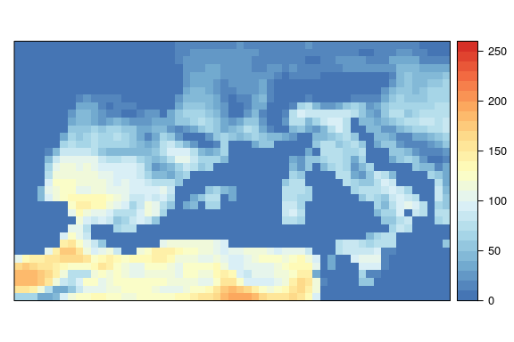

```r
SUh.annual <- aggregateGrid(SUh, aggr.y = list(FUN = "sum"))
spatialPlot(climatology(SUh.annual), at = seq(0, 260, 10),
            col.regions = colorRampPalette(colsindex))
```

### 2.1.3 Bias eobs vs cordex. Illustrates interpGrid

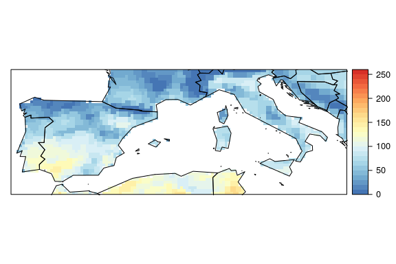

```r
SUh.interp <- interpGrid(SUh.annual, getGrid(SU.annual))

eobs.mask <- gridArithmetics(SU.annual, 0, operator = "*")
SUh.interp <- gridArithmetics(SUh.interp, eobs.mask, operator = "+")

bias <- gridArithmetics(SUh.interp, SU.annual, operator = "-")

spatialPlot(climatology(SUh.interp), backdrop.theme = "countries",
            at = seq(0, 260, 10), col.regions = colorRampPalette(colsindex))
```

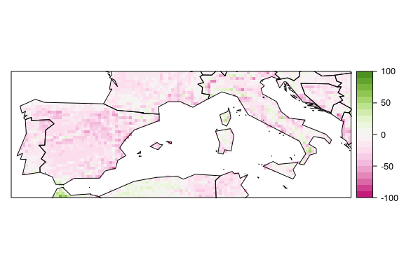

```r
spatialPlot(climatology(bias), backdrop.theme = "countries",
            at = seq(-100, 100, 10), col.regions = colorRampPalette(colsbias))#Negative bias
```

Loading data for the rcp8.5 scenario and period 2071-2100 using the same dictionary

```r
# the same dictionary
SUf <- loadGridData(dataset = "CDX_rcp85.ncml",
                     var = "tasmax",
                     season = 1:12,
                     lonLim = lon,
                     latLim = lat,
                     years = 2071:2100,
                     aggr.m = "sum",
                     threshold = 25,
                     condition = "GT",
                     dictionary = "dicCDX.dic")
```

```r
SUf.annual <- aggregateGrid(SUf, aggr.y = list(FUN = "sum"))
```

### 2.1.4 Calculate “Delta” signal

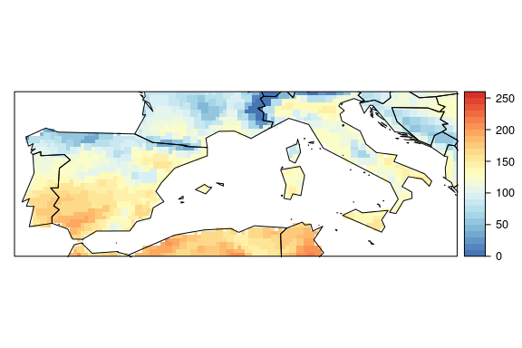

```r
SUf.interp <- interpGrid(SUf.annual, getGrid(SU.annual))
SUf.interp <- gridArithmetics(SUf.interp, eobs.mask, operator = "+")

CCsignal <- gridArithmetics(SUf.interp,
                            SUh.interp,
                            operator = "-")

spatialPlot(climatology(SUf.interp), backdrop.theme = "countries",
            at = seq(0, 260, 10), col.regions = colorRampPalette(colsindex))
```

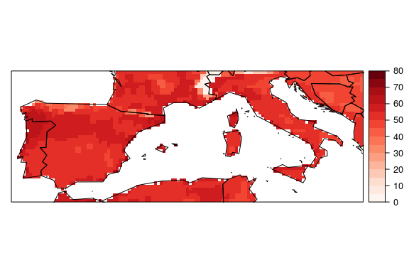

```r
spatialPlot(climatology(CCsignal), backdrop.theme = "countries",
            at = seq(0, 80, 5), col.regions = colorRampPalette(colsdelta))
```

## 2.2 Post-processing: Bias Correction

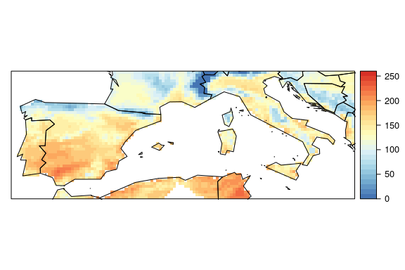

```r
SUf.bc <- biasCorrection(y = SU, x = SUh, newdata = SUf, method = "scaling", scaling.type = "additive")
SUf.bc.annual <- aggregateGrid(SUf.bc, aggr.y = list(FUN = "sum"))

CCsignal.bc <- gridArithmetics(SUf.bc.annual,
                            SU.annual,
                            operator = "-")

spatialPlot(climatology(SUf.bc.annual), backdrop.theme = "countries",
            at = seq(0, 260, 10), col.regions = colorRampPalette(colsindex))
```

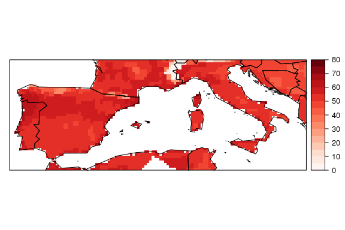

```r
spatialPlot(climatology(CCsignal.bc), backdrop.theme = "countries",
            at = seq(0, 80, 5), col.regions = colorRampPalette(colsdelta))
```

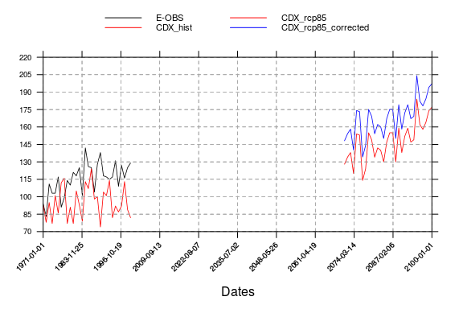

```r
Z <- lapply(list("E-OBS" = SU.annual, "CDX_hist" = SUh.interp,
                 "CDX_rcp85" = SUf.interp, "CDX_rcp85_corrected" = SUf.bc.annual),
            function(x)  subsetGrid(x, latLim = 41.64, lonLim = -0.89))
cols = c("black", "red", "red", "blue")
temporalPlot(Z, cols = cols, lwd = 0.8, xyplot.custom = list(ylab = "", ylim = c(70, 220),
  key = list(space = "top", lines = list(pch = 15, col = cols, cex = .5),
             text = list(names(Z),
                         cex = .7), columns = 2)))
```

## 2.3 Working with daily data

```r
TX <- loadGridData(eobs,
                   var = "tasmax",
                     season = 1:12,
                         lonLim = lon,
                         latLim = lat,
                         years = 1971:2000,
                         dictionary = "dicEOBS.dic")
TXh <- loadGridData(dataset = "CDX_hist.ncml",
                     var = "tasmax",
                     season = 1:12,
                     lonLim = lon,
                     latLim = lat,
                     years = 1971:2000,
                     dictionary = "dicCDX.dic")
TXf <- loadGridData(dataset = "CDX_rcp85.ncml",
                     var = "tasmax",
                     season = 1:12,
                     lonLim = lon,
                     latLim = lat,
                     years = 2071:2100,
                     dictionary = "dicCDX.dic")
TXf.bc <- biasCorrection(y = TX,
                         x = TXh,
                         newdata = TXf,
                         method = "eqm",
                         window = c(30, 7),
                         extrapolation = "constant")
SUf <- climdexGrid(tx = TXf, index.code = "SU")
SUf.bc <- climdexGrid(tx = TXf.bc, index.code = "SU")
```

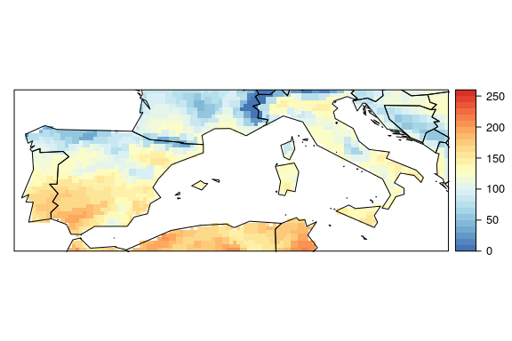

```r
SUf.interp <- interpGrid(SUf, getGrid(TX))
SUf.interp <- gridArithmetics(SUf.interp, eobs.mask, operator = "+")
spatialPlot(climatology(SUf.interp), backdrop.theme = "countries",
            at = seq(0, 260, 10), col.regions = colorRampPalette(colsindex))
```

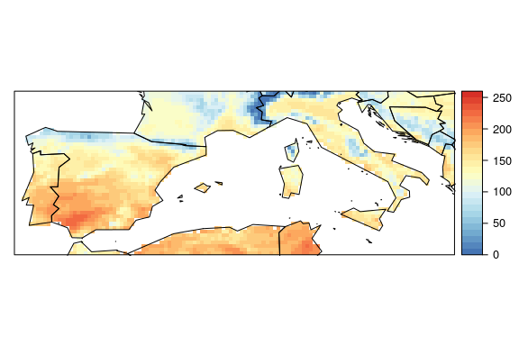

```r
spatialPlot(climatology(SUf.bc), backdrop.theme = "countries",
            at = seq(0, 260, 10), col.regions = colorRampPalette(colsindex))
```

# 3 Example 2: CORDEX Ensembles via the User Data Gateway

### 3.0.1 Cliamte data loading from UDG

The function `loginUDG` setup the UDG credentials for data access in the current R session:

```r
loginUDG("userUDG", "pswrdUDG")
```

```r
lon <- c(-10, 5)
lat <- c(36, 44)
```

#### 3.0.1.1 E-OBS obervation data

Loading with `loadGridData`:

```r
TX <- loadGridData(eobs,
                         var = "tasmax",
                         season = 1:12,
                         lonLim = lon,
                         latLim = lat,
                         years = 1971:2000,
                         dictionary = "dicEOBS.dic")
```

#### 3.0.1.2 Daily CORDEX data loading

```r
ds <- UDG.datasets()
ds$name[grepl("CORDEX44.*historical", ds$name)]
```

```
##  [1] EUROCORDEX44_ICHEC-EC-EARTH_r12i1p1_RCA4_v1_historical
##  [2] EUROCORDEX44_CERFACS-CNRM-CM5_r1i1p1_RCA4_v1_historical
##  [3] EUROCORDEX44_ICHEC-EC-EARTH_r1i1p1_RACMO22E_v1_historical
##  [4] EUROCORDEX44_ICHEC-EC-EARTH_r3i1p1_HIRHAM5_v1_historical
##  [5] EUROCORDEX44_IPSL-CM5A-MR_r1i1p1_RCA4_v1_historical
##  [6] EUROCORDEX44_MOHC-HadGEM2-ES_r1i1p1_RCA4_v1_historical
##  [7] EUROCORDEX44_MOHC-HadGEM2-ES_r1i1p1_RACMO22E_v1_historical
##  [8] EUROCORDEX44_MPI-ESM-LR_r1i1p1_CCLM4-8-17_v1_historical
##  [9] EUROCORDEX44_MPI-ESM-LR_r1i1p1_RCA4_v1_historical
## [10] EUROCORDEX44_IPSL-CM5A-MR_r1i1p1_WRF331F_v1_historical
## [11] EUROCORDEX44_MPI-CSC-MPI-M-MPI-ESM-LR_r1i1p1_REMO2009_v1_historical
## [12] EUROCORDEX44_MPI-CSC-MPI-M-MPI-ESM-LR_r2i1p1_REMO2009_v1_historical
## [13] AFRCORDEX44_KNMI-ICHEC-EC-EARTH_r1i1p1_RACMO22T_v1_historical
## [14] AFRCORDEX44_SMHI-CCCma-CanESM2_r1i1p1_RCA4_v1_historical
## [15] AFRCORDEX44_SMHI-CNRM-CERFACS-CNRM-CM5_r1i1p1_RCA4_v1_historical
## [16] AFRCORDEX44_SMHI-CSIRO-QCCCE-CSIRO-Mk3-6-0_r1i1p1_RCA4_v1_historical
## [17] AFRCORDEX44_SMHI-ICHEC-EC-EARTH_r12i1p1_RCA4_v1_historical
## [18] AFRCORDEX44_SMHI-IPSL-IPSL-CM5A-MR_r1i1p1_RCA4_v1_historical
## [19] AFRCORDEX44_SMHI-MIROC-MIROC5_r1i1p1_RCA4_v1_historical
## [20] AFRCORDEX44_SMHI-MOHC-HadGEM2-ES_r1i1p1_RCA4_v1_historical
## [21] AFRCORDEX44_SMHI-MPI-M-MPI-ESM-LR_r1i1p1_RCA4_v1_historical
## [22] AFRCORDEX44_SMHI-NCC-NorESM1-M_r1i1p1_RCA4_v1_historical
## [23] AFRCORDEX44_SMHI-NOAA-GFDL-GFDL-ESM2M_r1i1p1_RCA4_v1_historical
## 148 Levels: AFRCORDEX44_KNMI-ICHEC-EC-EARTH_r1i1p1_RACMO22T_v1_historical ...
```

```r
ensemble.h <- as.character(ds$url[grepl("EUROCORDEX44.*historical", ds$name)])[1:6]
```

```r
TXh.list <- lapply(ensemble.h, function(x)
                              loadGridData(dataset = x,
                              var = "tasmax",
                              season = 1:12,
                              lonLim = lon,
                              latLim = lat,
                              years = 1971:2000,
                              dictionary = "dicCDX.dic"))
```

```r
ensemble.f <- as.character(ds$url[grepl("EUROCORDEX44.*rcp85", ds$name)])[1:6]
TXf.list <- lapply(ensemble.f, function(x)
                          loadGridData(dataset = x,
                          var = "tasmax",
                          season = 1:12,
                          lonLim = lon,
                          latLim = lat,
                          years = 2071:2100,
                          dictionary = "dicCDX.dic"))
```

### 3.0.2 Data transformation

#### 3.0.2.1 Spatial and temporal consistency among members:

```r
# Temporal intersection
lapply(TXh.list, function(x) getShape(x))
```

```
## [[1]]
##  time   lat   lon
## 10958    26    32
##
## [[2]]
##  time   lat   lon
## 10958    26    32
##
## [[3]]
##  time   lat   lon
## 10958    26    32
##
## [[4]]
##  time   lat   lon
## 10958    26    32
##
## [[5]]
##  time   lat   lon
## 10950    26    32
##
## [[6]]
##  time   lat   lon
## 10748    26    32
```

```r
TXh.list <- do.call("intersectGrid.time", list(TXh.list, which.return = 1:6))
TXf.list <- do.call("intersectGrid.time", list(TXf.list, which.return = 1:6))
```

Interpolate to eobs:

```r
# Interpolation
TXh.list <- lapply(TXh.list, function(x) interpGrid(x, getGrid(TX)))
TXf.list <- lapply(TXf.list, function(x) interpGrid(x, getGrid(TX)))
```

```r
m <- TX$Data[1,,]*0
mask.hist <- array(dim = c(getShape(TXh.list[[1]])["time"], dim(m)))
for (i in 1:dim(mask.hist)[1]) mask.hist[i,,] <- m
mask.rcp <- array(dim = c(getShape(TXf.list[[1]])["time"], dim(m)))
for (i in 1:dim(mask.rcp)[1]) mask.rcp[i,,] <- m

# Apply mask
TXh.list <- lapply(TXh.list, function(x)
  gridArithmetics(x, mask.hist, operator = "+"))
TXf.list <- lapply(TXf.list, function(x)
  gridArithmetics(x, mask.rcp, operator = "+"))
```

#### 3.0.2.2 Create a multimember grid:

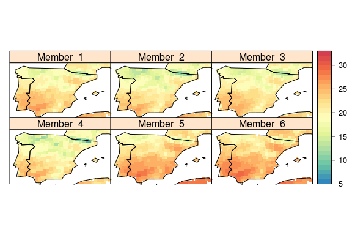

```r
# Create a multimember grid
TXh.ens <- do.call("bindGrid.member", TXh.list)
TXf.ens <- do.call("bindGrid.member", TXf.list)


spatialPlot(climatology(TXf.ens), at = seq(5, 33, 1), backdrop.theme = "countries",
            col.regions = colorRampPalette(colstx), layout = c(3, 2), as.table = TRUE)
```

calculate bias for maximum temperature

```r
# Create a multimember grid
TXh.list.ann <- lapply(TXh.list, function(x)
  aggregateGrid(x, aggr.y = list(FUN = "mean", na.rm = TRUE)))
TX.ann <- aggregateGrid(TX, aggr.y = list(FUN = "mean", na.rm = TRUE))
TXh.list.bias <- lapply(TXh.list.ann, function(x)
  gridArithmetics(x, TX.ann, operator = "-"))
```

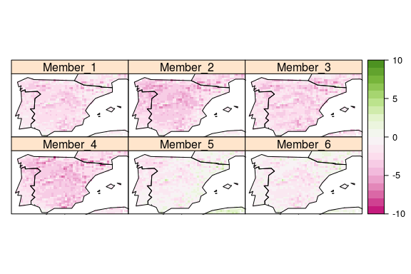

```r
TXh.bias.ens <- do.call("bindGrid.member", TXh.list.bias)
spatialPlot(climatology(TXh.bias.ens), at = seq(-10, 10, 1), backdrop.theme = "countries",
            col.regions = colorRampPalette(colsbias), layout = c(3, 2), as.table = TRUE)
```

We can use aggregateGrid to for example calculate the multimember mean and deviation

```r
TXf.ens.mean <- aggregateGrid(TXf.ens, aggr.mem = list(FUN = mean, na.rm = TRUE))
TXf.ens.sd <- aggregateGrid(TXf.ens, aggr.mem = list(FUN = sd, na.rm = TRUE))
```

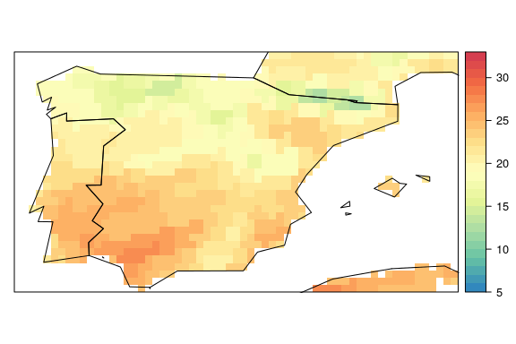

```r
spatialPlot(climatology(TXf.ens.mean), at = seq(5, 33, 1),
            col.regions = colorRampPalette(colstx), backdrop.theme = "countries")
```

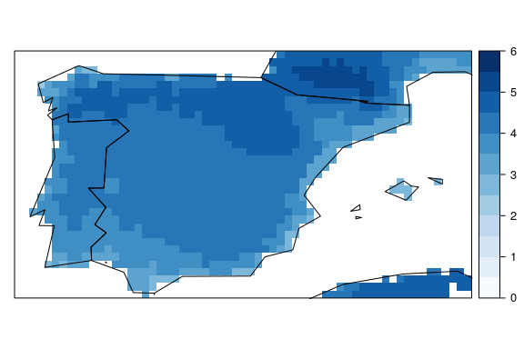

```r
spatialPlot(climatology(TXf.ens.sd), at = seq(0, 6, .5),
            col.regions = colorRampPalette(colssd), backdrop.theme = "countries")
```

### 3.0.3 ETCCDI index calculation from raw data

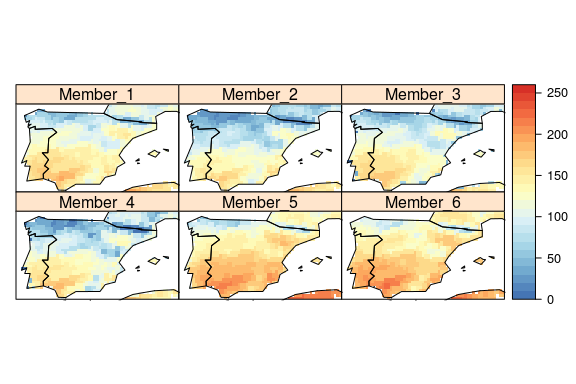

```r
SUf.ens <- climdexGrid(tx = TXf.ens, index.code = "SU")
spatialPlot(climatology(SUf.ens), backdrop.theme = "countries", at = seq(0, 260, 10),
            col.regions = colorRampPalette(colsindex), as.table = TRUE, layout = c(3, 2))
```

```r
SUf.ens.mean <- aggregateGrid(SUf.ens, aggr.mem = list(FUN = mean, na.rm = TRUE))
SUf.ens.sd <- aggregateGrid(SUf.ens, aggr.mem = list(FUN = sd, na.rm = TRUE))
```

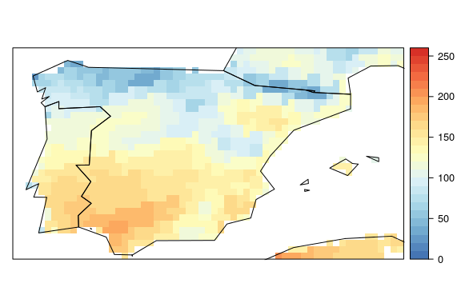

```r
spatialPlot(climatology(SUf.ens.mean), backdrop.theme = "countries",
            at = seq(0, 260, 10), col.regions = colorRampPalette(colsindex))
```

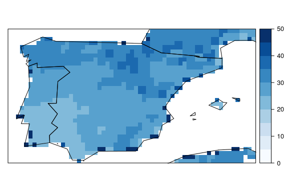

```r
spatialPlot(climatology(SUf.ens.sd), set.max = 50, backdrop.theme = "countries",
            at = seq(0, 50, 5), col.regions = colorRampPalette(colssd))
```

### 3.0.4 Bias correction

15 min operation

```r
TXf.ens.bc <- biasCorrection(TX,
                              TXh.ens,
                              TXf.ens,
                              window = c(30, 7),
                              extrapolation = "constant",
                              method = "eqm")
```

```r
TXf.ens.bc.mean <- aggregateGrid(TXf.ens.bc, aggr.mem = list(FUN = mean, na.rm = TRUE))
TXf.ens.bc.sd <- aggregateGrid(TXf.ens.bc, aggr.mem = list(FUN = sd, na.rm = TRUE))
```

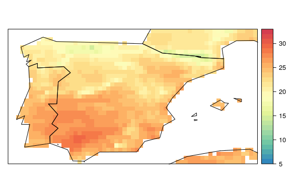

```r
spatialPlot(climatology(TXf.ens.bc.mean), backdrop.theme = "countries",
            at = seq(5, 33, 1), col.regions = colorRampPalette(colstx))
```

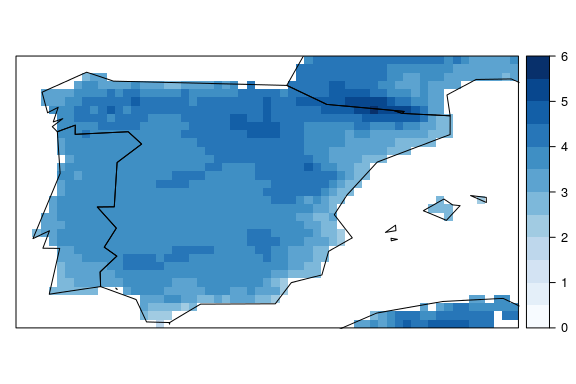

```r
spatialPlot(climatology(TXf.ens.bc.sd), backdrop.theme = "countries",
            at = seq(0, 6, .5), col.regions = colorRampPalette(colssd))
```

### 3.0.5 ETCCDI index calculation from bias corrected data

```r
SUf.ens.bc <- climdexGrid(tx = TXf.ens.bc, index.code = "SU")
```

```r
SUf.ens.bc.mean <- aggregateGrid(SUf.ens.bc, aggr.mem = list(FUN = mean, na.rm = TRUE))
SUf.ens.bc.sd <- aggregateGrid(SUf.ens.bc, aggr.mem = list(FUN = sd, na.rm = TRUE))
```

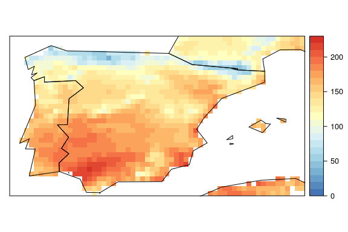

```r
spatialPlot(climatology(SUf.ens.bc.mean), backdrop.theme = "countries",
            at = seq(0, 230, 10), col.regions = colorRampPalette(colsindex))
```

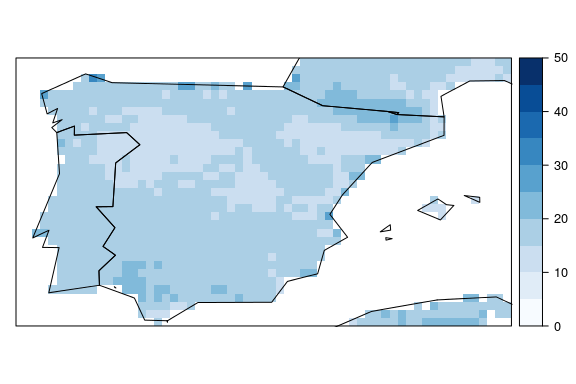

[figure not shown]

```r
spatialPlot(climatology(SUf.ens.bc.sd), backdrop.theme = "countries",
            at = seq(0, 50, 5), col.regions = colorRampPalette(colssd))
```

### 3.0.6 SU difference corrected non-corrected:

```r
SU.ens.bc.mean <- aggregateGrid(SUf.ens.bc, aggr.mem = list(FUN = mean, na.rm = TRUE))
SU.ens.bc.sd <- aggregateGrid(SUf.ens.bc, aggr.mem = list(FUN = sd, na.rm = TRUE))
```

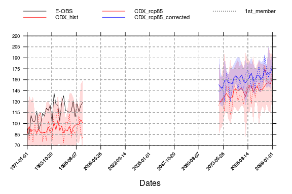

```r
#A single location
SU <- climdexGrid(tx = TX, index.code = "SU")
SUh.ens <- climdexGrid(tx = TXh.ens, index.code = "SU")

SU.Z.eobs <- subsetGrid(SU, latLim = 41.64, lonLim = -0.89)
SU.Z.cdx <- lapply(list(SUh.ens, SUf.ens, SUf.ens.bc), function(x)
                        subsetGrid(x, latLim = 41.64, lonLim = -0.89))
SU.Z.1m <- lapply(SU.Z.cdx, function(x)
                        subsetGrid(x, members = 1))
SU.Z <- c(list(SU.Z.eobs), SU.Z.cdx, SU.Z.1m)
cols  <- c("black", rep(c("red", "red", "blue"), 2))
temporalPlot(SU.Z,
             cols = cols,
             lty = rep(c(1,3), each = 4),
             lwd = 0.8,
             xyplot.custom = list(ylim = c(70, 220), ylab = "",
                                  key = list(space = "top", lines = list(lty = c(rep(1,4), 3),
                                                                         col = c(cols[1:4], cols[1]),
                                                                         lwd = 0.8),
                                             text = list(c("E-OBS", "CDX_hist", "CDX_rcp85", "CDX_rcp85_corrected",
                                                           "1st_member"),
                                                         cex = .7),
                                             columns = 3, rows = 3)))
```

### 3.0.7 Calculate other indexes

```r
climdexShow()[,1:6]
```

#### 3.0.7.1 Calculate CDD

```r
eobs.pr <- "http://opendap.knmi.nl/knmi/thredds/dodsC/e-obs_0.25regular/rr_0.25deg_reg_v16.0.nc"
write(c("identifier,short_name,time_step,lower_time_bound,upper_time_bound,cell_method,offset,scale,deaccum,derived,interface",
             "tasmax,tx,24h,0,24,max,0,1,0,0,",
        "pr,rr,24h,0,24,max,0,1,0,0,"), "dicEOBS.dic")
pr <- loadGridData(eobs.pr,
                         var = "pr",
                         season = 1:12,
                         lonLim = lon,
                         latLim = lat,
                         years = 1971:2000,
                         dictionary = "dicEOBS.dic")
write(c("identifier,short_name,time_step,lower_time_bound,upper_time_bound,cell_method,offset,scale,deaccum,derived,interface",
             "tasmax,tasmax,24h,0,24,max,-273.15,1,0,0,",
             "pr,pr,24h,0,24,max,0,86400,0,0,"), "dicCDX.dic")
prh <- lapply(ensemble.h, function(x)
                              loadGridData(dataset = x,
                              var = "pr",
                              season = 1:12,
                              lonLim = lon,
                              latLim = lat,
                              years = 1971:2000,
                              dictionary = "dicCDX.dic"))
prf <- lapply(ensemble.f, function(x)
                          loadGridData(dataset = x,
                          var = "pr",
                          season = 1:12,
                          lonLim = lon,
                          latLim = lat,
                          years = 2071:2100,
                          dictionary = "dicCDX.dic"))
prh.t <- do.call("intersectGrid.time", list(prh, which.return = 1:6))
prf.t <- do.call("intersectGrid.time", list(prf, which.return = 1:6))
prh.ens <- do.call("bindGrid.member", prh.t)
prf.ens <- do.call("bindGrid.member", prf.t)
```

```r
CDDf.ens <- climdexGrid(pr = prf.ens, index.code = "CDD")
CDDf.ens.interp <- interpGrid(CDDf.ens, getGrid(pr))
CDDf.ens.mean <- aggregateGrid(CDDf.ens.interp, aggr.mem = list(FUN = "mean", na.rm = TRUE))
CDDf.ens.sd <- aggregateGrid(CDDf.ens.interp, aggr.mem = list(FUN = "sd", na.rm = TRUE))

m <- pr$Data[1,,]*0
mask.cdd <- array(dim = c(getShape(CDDf.ens.mean)["time"], dim(m)))
for (i in 1:dim(mask.cdd)[1]) mask.cdd[i,,] <- m
CDDf.ens.mean <- gridArithmetics(CDDf.ens.mean, mask.cdd, operator = "+")
CDDf.ens.sd <- gridArithmetics(CDDf.ens.sd, mask.cdd, operator = "+")
```

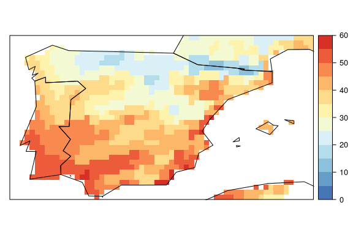

```r
spatialPlot(climatology(CDDf.ens.mean), backdrop.theme = "countries", at = seq(0, 60, 5),
            col.regions = colorRampPalette(colsindex))
```

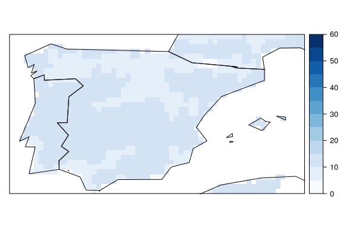

```r
spatialPlot(climatology(CDDf.ens.sd), backdrop.theme = "countries", at = seq(0, 60, 5),
            col.regions = colorRampPalette(colssd))
```

```r
prf.ens.bc <- biasCorrection(y = pr,
                                    x = prh.ens,
                                    newdata = prf.ens,
                                    precipitation = TRUE,
                                    window = c(30, 7),
                                    extrapolation = "constant",
                                    method = "eqm",
                                    wet.threshold = 0.1)
CDDf.ens.bc <- climdexGrid(pr = prf.ens.bc, index.code = "CDD")
CDDf.ens.bc.mean <- aggregateGrid(CDDf.ens.bc, aggr.mem = list(FUN = "mean", na.rm = TRUE))
CDDf.ens.bc.sd <- aggregateGrid(CDDf.ens.bc, aggr.mem = list(FUN = "sd", na.rm = TRUE))
```

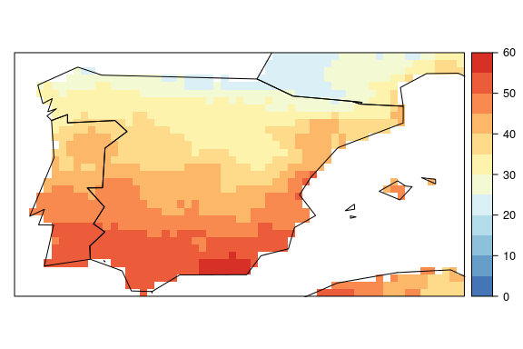

```r
spatialPlot(climatology(CDDf.ens.bc.mean), backdrop.theme = "countries", at = seq(0, 60, 5),
            col.regions = colorRampPalette(colsindex))
```

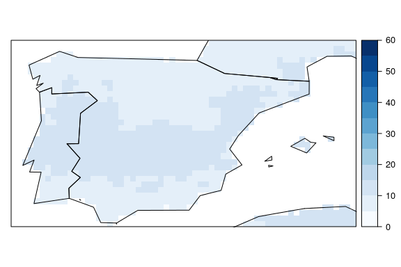

```r
spatialPlot(climatology(CDDf.ens.bc.sd), backdrop.theme = "countries", at = seq(0, 60, 5),
            col.regions = colorRampPalette(colssd))
```